# Matchup of Matchups Plots and Tables

Chirag Kumar and Guillermo Podesta

October 8, 2016

We will explore patterns in collocated and temporally-similar (within 2 hours) night-time buoy MODIS AQUA and VIIRS retrievals and how those patterns change when only records where both AQUA and VIIRS SSTs have a quality level of 0.

orig_solz_platform_time are the collocated and temporally-similar night-time buoy AQUA and VIIRS retrievals.

orig_filtered is orig_solz_platform_time where only retrievals where both AQUA and VIIRS quality levels are 0.

Anything ending in “.x” refers to the value coming from MODIS AQUA retrievals and “.y” is from VIIRS.

## Cross-Tabulation Tables

### orig_solz_platform_time

This table shows the cross tabulation of quality levels in AQUA and VIIRS matchups from orig_solz_platform_time. Note the large quantity of AQUA retrievals that have a quality of 3 when their respective VIIRS counterparts have a quality level of 0.

```r
xtabs(~ qsst.x + qsst.y, data = orig_solz_platform_time)
```

```
##       qsst.y
## qsst.x     0     1     2     3
##      0 61460 21223   273  8552
##      1 29864 10486   218  4786
##      2 25386  9540   365  3987
##      3 30997 12631  2883 53180
##      4   228    94     0    25
```

# Plots of features in AQUA and VIIRS matchups

Here we attempt plot features in the AQUA and VIIRS matchups to (a) check that the joining and filtering has been implemented correctly and (b) identify any other discrepancies that could help us understand the quality discrepancy. For every feature we explore, we will explore it both in orig_solz_platform_time and orig_filtered. *ggplot2* will be used to do the plotting

## Plot of SSTs

### orig_solz_platform_time

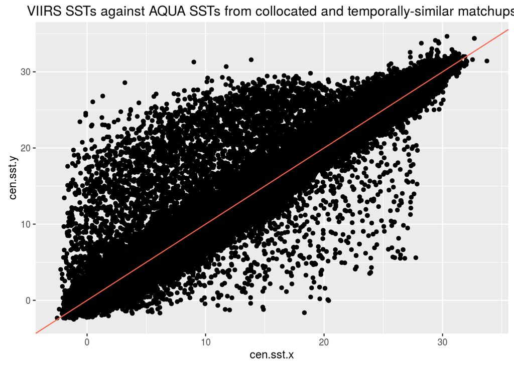

```r
ggplot2::ggplot(data = orig_solz_platform_time, mapping = aes(x = cen.sst.x, y = cen.sst.y)) +
  geom_point() +
  geom_abline(intercept = 0, slope = 1, color = "tomato") +
  ggtitle("VIIRS SSTs against AQUA SSTs from collocated and temporally-similar matchups")
```

### orig_filtered

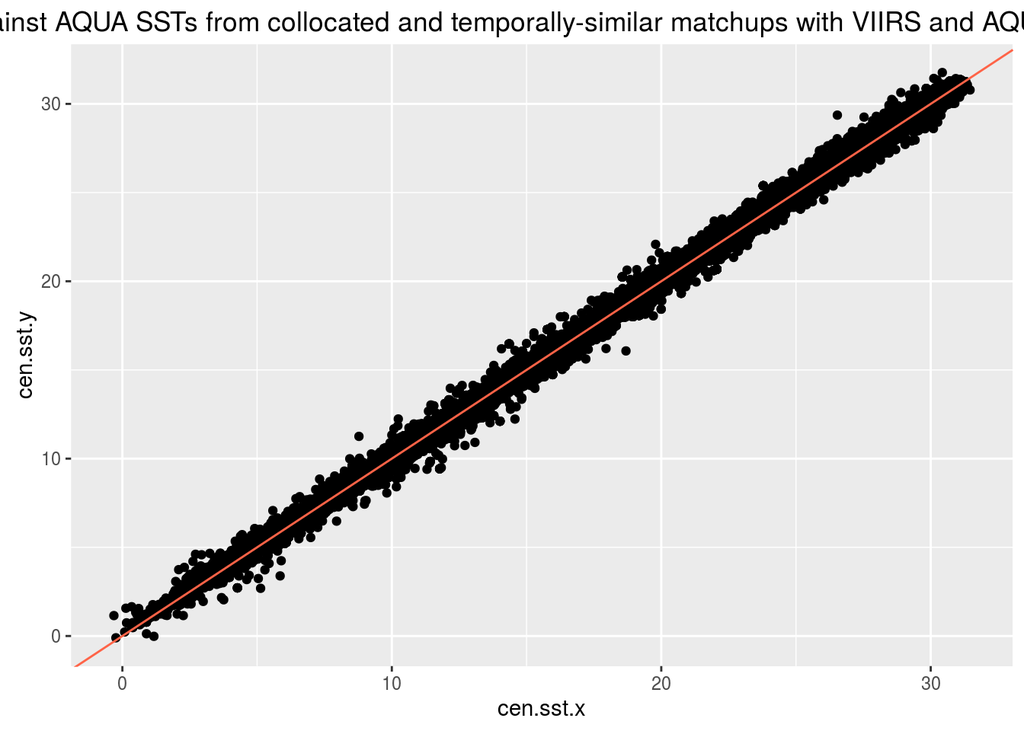

```r
ggplot2::ggplot(data = orig_filtered, mapping = aes(x = cen.sst.x, y = cen.sst.y)) +
  geom_point() +
  geom_abline(intercept = 0, slope = 1, color = "tomato") +
  ggtitle("VIIRS SSTs against AQUA SSTs from collocated and temporally-similar matchups with VIIRS and AQUA quality levels of 0")
```

Notice that much of the deviation from the $y = x$ line in the first plot is removed when we constrict the data to only matchups with both AQUA and VIIRS qualities equal to 0. To explore the quality discrepancies more, let us look at a plot where we include matchups where AQUA **or** VIIRS matchups have a quality level of 0.

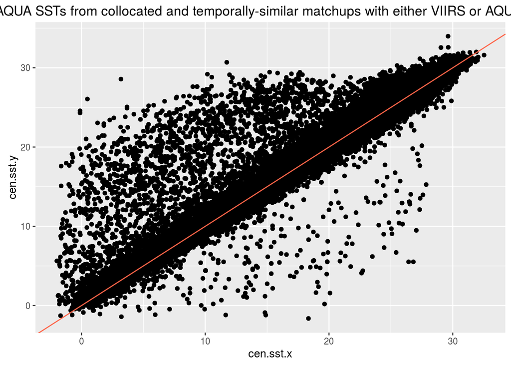

```r
ggplot2::ggplot(data = orig_solz_platform_time %>%
    dplyr::filter(qsst.x == 0 | qsst.y == 0), mapping = aes(x = cen.sst.x, y = cen.sst.y)) +
  geom_point() +
  geom_abline(intercept = 0, slope = 1, color = "tomato") +
  ggtitle("VIIRS SSTs against AQUA SSTs from collocated and temporally-similar matchups with either VIIRS or AQUA quality levels equal to 0")
```

Again, we see much of the same spread as in the first plot. To see if the spread points are coming from AQUA or VIIRS matchups, let us do two plots. One will have only matchups where AQUA’s quality level is equal to 0. The other will have only matchups where VIIRS’s quality level is equal to 0.

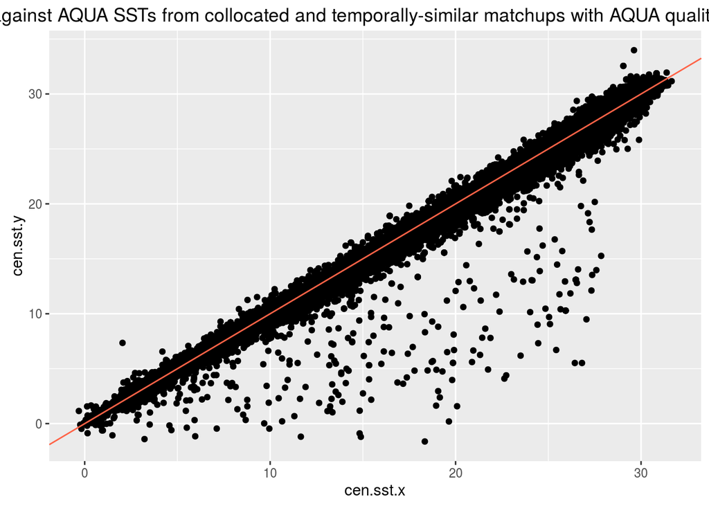

```r
ggplot2::ggplot(data = orig_solz_platform_time %>%
    dplyr::filter(qsst.x == 0), mapping = aes(x = cen.sst.x, y = cen.sst.y)) +
  geom_point() +
  geom_abline(intercept = 0, slope = 1, color = "tomato") +
  ggtitle("VIIRS SSTs against AQUA SSTs from collocated and temporally-similar matchups with AQUA quality levels equal to 0")
```

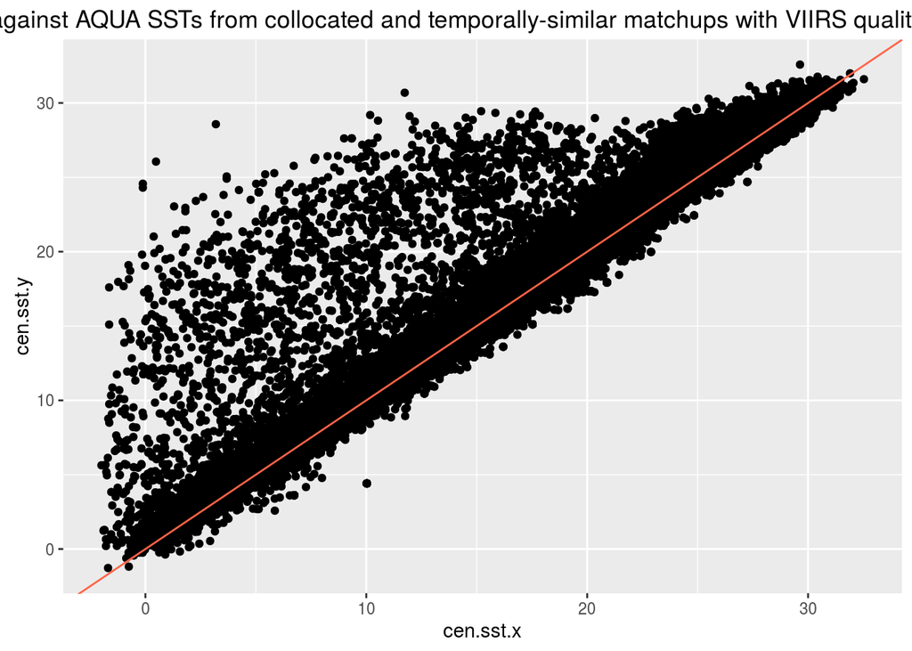

```r
ggplot2::ggplot(data = orig_solz_platform_time %>%
    dplyr::filter(qsst.y == 0), mapping = aes(x = cen.sst.x, y = cen.sst.y)) +
  geom_point() +
  geom_abline(intercept = 0, slope = 1, color = "tomato") +
  ggtitle("VIIRS SSTs against AQUA SSTs from collocated and temporally-similar matchups with VIIRS quality levels equal to 0")
```